# Estudo de caso Bellabeat

Vinícius Maia

2025-03-10

# **Estudo de caso Bellabeat**

## **A Bellabeat**:

##### É uma empresa de alta tecnologia que fabrica produtos inteligentes focados na saúde. A Urška aproveitou sua experiência como artista para desenvolver uma tecnologia elegantemente projetada que informa e inspira mulheres em todo o mundo. A coleta de dados sobre atividade, sono, estresse e saúde reprodutiva permitiu à Bellabeat capacitar as mulheres com conhecimento sobre sua própria saúde e hábitos. A Urška sabe que uma análise dos dados de consumo disponíveis da Bellabeat revelaria mais oportunidades de crescimento.

## Perguntas sobre a análise:

##### 1. Quais são algumas das tendências no uso de dispositivos inteligentes?

##### 2. Como essas tendências podem se aplicar aos clientes da Bellabeat?

##### 3. Como essas tendências podem ajudar a influenciar a estratégia de marketing da Bellabeat?

## Objetivo de Negócios:

##### Identificar possíveis oportunidades de crescimento e recomendações para melhoria da estratégia de marketing da Bellabeat, com base nas tendências em uso de dispositivos inteligentes.

## **Carregando e instalando pacotes**:

```r
library(tidyverse)
library(janitor)
```

```r
library(ggplot2)
library(dplyr)
library(tidyr)
library(lubridate)
```

## **Importando os conjuntos**:

```r
atividade <- read_csv("C:/Users/wcwil/Desktop/analise-portfolio-fitbit/mturkfitbit_export_4.12.16-5.12.16/Fitabase Data 4.12.16-5.12.16/dailyActivity_merged.csv") %>% clean_names()
calorias <- read_csv("C:/Users/wcwil/Desktop/analise-portfolio-fitbit/mturkfitbit_export_4.12.16-5.12.16/Fitabase Data 4.12.16-5.12.16/hourlyCalories_merged.csv") %>% clean_names()
intensidade <- read_csv("C:/Users/wcwil/Desktop/analise-portfolio-fitbit/mturkfitbit_export_4.12.16-5.12.16/Fitabase Data 4.12.16-5.12.16/hourlyIntensities_merged.csv") %>% clean_names()
sono <- read_csv("C:/Users/wcwil/Desktop/analise-portfolio-fitbit/mturkfitbit_export_4.12.16-5.12.16/Fitabase Data 4.12.16-5.12.16/sleepDay_merged.csv") %>% clean_names()
batimentos <- read_csv("C:/Users/wcwil/Desktop/analise-portfolio-fitbit/mturkfitbit_export_4.12.16-5.12.16/Fitabase Data 4.12.16-5.12.16/heartrate_seconds_merged.csv") %>% clean_names()
peso <- read_csv("C:/Users/wcwil/Desktop/analise-portfolio-fitbit/mturkfitbit_export_4.12.16-5.12.16/Fitabase Data 4.12.16-5.12.16/weightLogInfo_merged.csv") %>% clean_names()
```

O uso do **clean_names()** padroniza os nomes das colunas, tornando-as mais organizadas e fáceis de manipular.

## **Manipulação e Limpeza dos dados**:

```r
head(atividade)
```

```
## # A tibble: 6 × 15
##           id activity_date total_steps total_distance tracker_distance
##        <dbl> <chr>               <dbl>          <dbl>            <dbl>
## 1 1503960366 4/12/2016           13162           8.5              8.5
## 2 1503960366 4/13/2016           10735           6.97             6.97
## 3 1503960366 4/14/2016           10460           6.74             6.74
## 4 1503960366 4/15/2016            9762           6.28             6.28
## 5 1503960366 4/16/2016           12669           8.16             8.16
## 6 1503960366 4/17/2016            9705           6.48             6.48
## # ℹ 10 more variables: logged_activities_distance <dbl>,
## #   very_active_distance <dbl>, moderately_active_distance <dbl>,
## #   light_active_distance <dbl>, sedentary_active_distance <dbl>,
## #   very_active_minutes <dbl>, fairly_active_minutes <dbl>,
## #   lightly_active_minutes <dbl>, sedentary_minutes <dbl>, calories <dbl>
```

```r
head(calorias)
```

```
## # A tibble: 6 × 3
##           id activity_hour         calories
##        <dbl> <chr>                    <dbl>
## 1 1503960366 4/12/2016 12:00:00 AM       81
## 2 1503960366 4/12/2016 1:00:00 AM        61
## 3 1503960366 4/12/2016 2:00:00 AM        59
## 4 1503960366 4/12/2016 3:00:00 AM        47
## 5 1503960366 4/12/2016 4:00:00 AM        48
## 6 1503960366 4/12/2016 5:00:00 AM        48
```

```r
head(sono)
```

```
## # A tibble: 6 × 5
##          id sleep_day total_sleep_records total_minutes_asleep total_time_in_bed
##       <dbl> <chr>                   <dbl>                <dbl>             <dbl>
## 1    1.50e9 4/12/201…                   1                  327               346
## 2    1.50e9 4/13/201…                   2                  384               407
## 3    1.50e9 4/15/201…                   1                  412               442
## 4    1.50e9 4/16/201…                   2                  340               367
## 5    1.50e9 4/17/201…                   1                  700               712
## 6    1.50e9 4/19/201…                   1                  304               320
```

```r
head(intensidade)
```

```
## # A tibble: 6 × 4
##           id activity_hour         total_intensity average_intensity
##        <dbl> <chr>                           <dbl>             <dbl>
## 1 1503960366 4/12/2016 12:00:00 AM              20             0.333
## 2 1503960366 4/12/2016 1:00:00 AM                8             0.133
## 3 1503960366 4/12/2016 2:00:00 AM                7             0.117
## 4 1503960366 4/12/2016 3:00:00 AM                0             0
## 5 1503960366 4/12/2016 4:00:00 AM                0             0
## 6 1503960366 4/12/2016 5:00:00 AM                0             0
```

```r
head(batimentos)
```

```
## # A tibble: 6 × 3
##           id time                 value
##        <dbl> <chr>                <dbl>
## 1 2022484408 4/12/2016 7:21:00 AM    97
## 2 2022484408 4/12/2016 7:21:05 AM   102
## 3 2022484408 4/12/2016 7:21:10 AM   105
## 4 2022484408 4/12/2016 7:21:20 AM   103
## 5 2022484408 4/12/2016 7:21:25 AM   101
## 6 2022484408 4/12/2016 7:22:05 AM    95
```

```r
head(peso)
```

```
## # A tibble: 6 × 8
##           id date   weight_kg weight_pounds   fat   bmi is_manual_report  log_id
##        <dbl> <chr>      <dbl>         <dbl> <dbl> <dbl> <lgl>              <dbl>
## 1 1503960366 5/2/2…      52.6          116.    22  22.6 TRUE             1.46e12
## 2 1503960366 5/3/2…      52.6          116.    NA  22.6 TRUE             1.46e12
## 3 1927972279 4/13/…     134.           294.    NA  47.5 FALSE            1.46e12
## 4 2873212765 4/21/…      56.7          125.    NA  21.5 TRUE             1.46e12
## 5 2873212765 5/12/…      57.3          126.    NA  21.7 TRUE             1.46e12
## 6 4319703577 4/17/…      72.4          160.    25  27.5 TRUE             1.46e12
```

##### Após inspecionar os conjuntos, identifiquei uma dissociação dos horários e datas.

```r
intensidade <- intensidade %>%
  mutate(activity_hour=as.POSIXct(activity_hour, format = "%m/%d/%Y %I:%M:%S %p", tz = "UTC"))
intensidade$hora <- format(intensidade$activity_hour, format = "%H:%M:%S")
intensidade$data <- format(intensidade$activity_hour, format = "%m/%d/%y")

calorias$activity_hour=as.POSIXct(calorias$activity_hour, format="%m/%d/%Y %I:%M:%S %p", tz="UTC")
calorias$hora <- format(calorias$activity_hour, format = "%H:%M:%S")
calorias$data <- format(calorias$activity_hour, format = "%m/%d/%y")

atividade$activity_date=as.POSIXct(atividade$activity_date, format = "%m/%d/%Y", tz="UTC")
atividade$data <- format(atividade$activity_date,format="%m/%d/%y")

sono$sleep_day=as.POSIXct(sono$sleep_day, format="%m/%d/%Y %I:%M:%S %p", tz="UTC")
sono$data <- format(sono$sleep_day, format="%m/%d/%y")

batimentos$time=as.POSIXct(batimentos$time, format="%m/%d/%Y %I:%M:%S %p", tz ="UTC")
batimentos$hora <- format(batimentos$time, format = "%H:%M:%S")
batimentos$data <- format(batimentos$time, format="%m/%d/%y")

peso <- peso %>%
  mutate(date=as.POSIXct(date, format = "%m/%d/%Y %I:%M:%S %p", tz = "UTC"))
peso$hora <- format(peso$date, format = "%H:%M:%S")
peso$data <- format(peso$date, format = "%m/%d/%y")
```

##### Após **padronizar as colunas em data e hora**, podemos explorar os dados.

## **Exploração e Resumo dos dados**:

```r
atividade %>%
  select(total_steps, total_distance, sedentary_minutes, calories) %>%
  summary()
```

```
##   total_steps    total_distance   sedentary_minutes    calories
##  Min.   :    0   Min.   : 0.000   Min.   :   0.0    Min.   :   0
##  1st Qu.: 3790   1st Qu.: 2.620   1st Qu.: 729.8    1st Qu.:1828
##  Median : 7406   Median : 5.245   Median :1057.5    Median :2134
##  Mean   : 7638   Mean   : 5.490   Mean   : 991.2    Mean   :2304
##  3rd Qu.:10727   3rd Qu.: 7.713   3rd Qu.:1229.5    3rd Qu.:2793
##  Max.   :36019   Max.   :28.030   Max.   :1440.0    Max.   :4900
```

```r
atividade %>%
  select(very_active_minutes, fairly_active_minutes, lightly_active_minutes)%>%
  summary()
```

```
##  very_active_minutes fairly_active_minutes lightly_active_minutes
##  Min.   :  0.00      Min.   :  0.00        Min.   :  0.0
##  1st Qu.:  0.00      1st Qu.:  0.00        1st Qu.:127.0
##  Median :  4.00      Median :  6.00        Median :199.0
##  Mean   : 21.16      Mean   : 13.56        Mean   :192.8
##  3rd Qu.: 32.00      3rd Qu.: 19.00        3rd Qu.:264.0
##  Max.   :210.00      Max.   :143.00        Max.   :518.0
```

```r
 calorias %>%
  select(calories) %>%
  summary()
```

```
##     calories
##  Min.   : 42.00
##  1st Qu.: 63.00
##  Median : 83.00
##  Mean   : 97.39
##  3rd Qu.:108.00
##  Max.   :948.00
```

```r
 sono %>%
   select(total_minutes_asleep, total_time_in_bed) %>%
 summary()
```

```
##  total_minutes_asleep total_time_in_bed
##  Min.   : 58.0        Min.   : 61.0
##  1st Qu.:361.0        1st Qu.:403.0
##  Median :433.0        Median :463.0
##  Mean   :419.5        Mean   :458.6
##  3rd Qu.:490.0        3rd Qu.:526.0
##  Max.   :796.0        Max.   :961.0
```

```r
 peso %>%
  select(weight_kg, bmi)%>%
  summary()
```

```
##    weight_kg           bmi
##  Min.   : 52.60   Min.   :21.45
##  1st Qu.: 61.40   1st Qu.:23.96
##  Median : 62.50   Median :24.39
##  Mean   : 72.04   Mean   :25.19
##  3rd Qu.: 85.05   3rd Qu.:25.56
##  Max.   :133.50   Max.   :47.54
```

```r
batimentos %>%
  summarise(
    bpm_medio = mean(value, na.rm = TRUE),
    bpm_mediano = median(value, na.rm = TRUE),
    bpm_desvio = sd(value, na.rm = TRUE))
```

```
## # A tibble: 1 × 3
##   bpm_medio bpm_mediano bpm_desvio
##       <dbl>       <dbl>      <dbl>
## 1      77.3          73       19.4
```

### **Análise e Interpretação sobre os dados**:

##### A média de passos dados e de distância percorrida demonstram um padrão de atividade bom dos usuários.

##### A queima calórica não está tão acentuada, mostrando um padrão de atividade mais leve, inclusive corroborando com a média da coluna dos minutos levemente ativos.

##### O ponto negativo e expressivo fica pros minutos sedentários, onde a média de 991 minutos demonstra um padrão que precisa ser corrigido.

##### A frequência cardíaca apresentou médias e medianas dentro da normalidade, porém, o desvio padrão elevado sugere uma variabilidade significativa, possivelmente influenciada por fatores clínicos comuns como ansiedade e estresse, considerando que a atividade leve foi predominante. Notificações com incentivo ao uso de um aplicativo de Atenção Plena pode ser interessante, mas não substitui avaliações médicas.

## **Transformação de dados**:

```r
atividade_long <- atividade %>%
  select(id, calories, lightly_active_minutes, fairly_active_minutes) %>%
  pivot_longer(cols = c(lightly_active_minutes, fairly_active_minutes),
               names_to = "nivel_de_atividade1",
               values_to =  "minutos") %>%
  mutate(nivel_atividade = recode(nivel_de_atividade1,
                                  "lightly_active_minutes" = "atividade moderada",
                                  "fairly_active_minutes" = "atividade intensa"))

head(atividade_long)
```

```
## # A tibble: 6 × 5
##           id calories nivel_de_atividade1    minutos nivel_atividade
##        <dbl>    <dbl> <chr>                    <dbl> <chr>
## 1 1503960366     1985 lightly_active_minutes     328 atividade moderada
## 2 1503960366     1985 fairly_active_minutes       13 atividade intensa
## 3 1503960366     1797 lightly_active_minutes     217 atividade moderada
## 4 1503960366     1797 fairly_active_minutes       19 atividade intensa
## 5 1503960366     1776 lightly_active_minutes     181 atividade moderada
## 6 1503960366     1776 fairly_active_minutes       11 atividade intensa
```

##### Agrupei os minutos de atividade em uma única coluna **minutos**, e criei uma variável categórica **nível_atividade** que indica se os dados se referem à atividade moderada ou intensa.

## **Visualizações**:

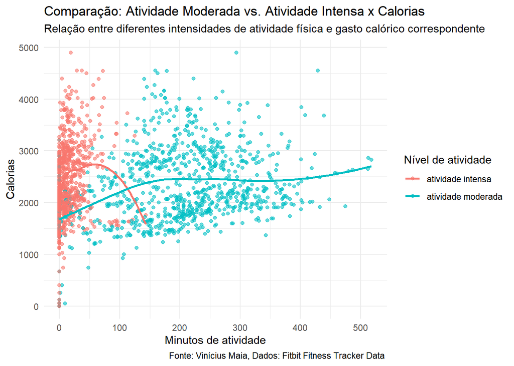

```r
ggplot(atividade_long, aes(x = minutos, y = calories, color = nivel_atividade))+
    geom_point(alpha = 0.6)+
    geom_smooth(method = "loess", se = FALSE)+
    theme_minimal()+
    labs(title = "Comparação: Atividade Moderada vs. Atividade Intensa x Calorias",
  subtitle = "Relação entre diferentes intensidades de atividade física e gasto calórico correspondente",
  x = "Minutos de atividade",
       y = "Calorias",
       color= "Nível de atividade",
       caption = "Fonte: Vinícius Maia, Dados: Fitbit Fitness Tracker Data ")
```

```r
  scale_color_manual(values = c("atividade moderada" = "blue",
                                "atividade intensa" = "red"))
```

[output not shown]

### **Análise Complementar**:

##### Após observar a relação entre minutos de atividade e calorias queimadas, achei pertinente investigar quanto tempo, os usuários passam em cada nível de atividade. Para isso, criei um gráfico de barras que apresenta o tempo médio de atividade moderada e intensa.

[figure not shown]

```r
atividade_long %>%
    group_by(nivel_atividade) %>%
    summarise(media_minutos = mean(minutos, na.rm = TRUE)) %>%
    ggplot(aes(x = nivel_atividade, y = media_minutos, fill = nivel_atividade))+
    geom_col()+
    theme_minimal()+
    labs(title =  "Tempo Médio de Atividade por Nível de Intensidade",
         caption = "Fonte: Vinícius Maia, Dados: Fitbit Fitness Tracker Data",
         x = "Nível de Atividade",
         y = "Tempo Médio (Minutos)",
         fill = "Nível de Atividade")+
    scale_fill_manual(values = c("lightblue", "red"),
                      labels = c("atividade moderada", "atividade intensa"))
```

## **Sugestões para a equipe de Marketing da Bellabeat**:

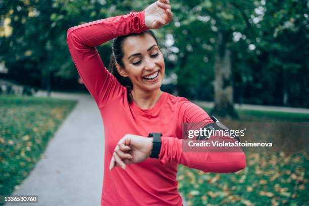

Corrida menos intensa e mais regular é uma boa opção pra manter a constância de exercício.

##### Sugerir treinos personalizados, equilibrando atividades moderadas e intensas para otimizar o gasto calórico e a adesão das usuárias.

##### Criar desafios e metas realistas, incentivando as usuárias a aumentar progressivamente o tempo em atividades intensas ou manter uma rotina constante de atividades moderadas.

##### Fornecer feedback baseado nos padrões da usuária, recomendando ajustes de intensidade dos treinos conforme a resistência e regularidade da atividade física.

### Essas descobertas mostram como os dados podem ser utilizados para personalizar experiências e tornar a prática de exercícios mais eficiente e adaptada às necessidades individuais, assim, afastando o sedentarismo e trazendo um estilo de vida mais saudável a usuária.

##### Com a crescente demanda por bem estar e saúde mental, a Bellabeat pode expandir suas campanhas para abordar não apenas a atividade física, mas também a saúde mental. Isso pode incluir:

##### Incluir meditação e mindfulness nas funcionalidades do produto e promover isso nas campanhas de marketing

##### Realçar o impacto do equilíbrio entre atividade, sono e saúde mental nas campanhas de engajamento.

##### Integração com dispositivos weareble para monitorar níveis de estresse através da variabilidade de frequência cardíaca (HRV) e sugerir momentos de pausa e relaxamento.

##### Introdução de um índice de bem-estar personalizado, baseado na combinação de dados de sono, atividade e níveis de estresse, ajudando as usuárias a acompanharem seu progresso ao longo do tempo.

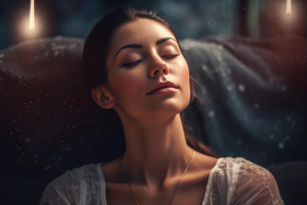

Atenção Plena consiste em prestar atenção enquanto respira e inspira profundamente

## **Conclusão**:

##### A Bellabeat pode se diferenciar no mercado ao posicionar-se como uma marca que não cuida apenas do corpo, mas também do bem estar das usuárias. Essa abordagem pode ser usada para atrair um público ainda maior, incluindo pessoas que buscam um estilo de vida mais equilibrado e consciente. Com base nos insights, recomenda-se que a Bellabeat segmente suas usuárias para personalizar campanhas de marketing, desenvolva funcionalidades que promovam tanto a atividade física quanto o bem-estar mental, e crie programas que incentivem hábitos saudáveis de forma integrada.